# Introduction to Species Distribution Models

January 21, 2018

## What are species distribution models (SDMs)?

"Species distribution models (SDMs) are numerical tools that combine observations of species occurrence or abundance with environmental estimates. They are used to gain ecological and evolutionary insights and to predict distributions across landscapes, sometimes requiring extrapolation in space and time." – Elith & Leathwick 2009

Elith, J. and Leathwick, J.R., 2009. Species distribution models: ecological explanation and prediction across space and time. Annual review of ecology, evolution, and systematics, 40, pp.677-697.

## Types of SDMs

- Type of statistical models
  - Frequentist
  - Bayesian
  - Machine learning

## Types of SDMs, cont'd

- Type of response variables
  - Presence/absence (occurrence)
  - Count (abundance)
- Number of response variables
  - One
    - single species
    - Uni-directional interspecific interactions (B -> A)
  - Two or more: multiple species
    - Interspecific similarity
    - Undirectional interspecific interactions (A - B)
    - Bi-directional interspecific interactions (A -> B & B -> A)

## Types of SDMs, cont'd

- Temporal processes represented
  - No: static
  - Yes: dynamic
- Spatial processes represented
  - No
  - Implicitly (spatial autocorrelation)
  - Explicitly (dynamic)

## Basic frequetist SDMs (that no one uses)

- Occurrence: logistic regression \[y \sim Bernoulli(\pi)\] \[logit(\pi) = X\beta\]
- Abundance: Poisson regression \[N \sim Poisson(\lambda)\] \[log(\lambda)=X\beta\]

## Two directions of extension

|  | Machine learning (non-parametric) | Bayesian (parametric) |
| --- | --- | --- |
| Non-linear relationship | Easy to detect | Hard to detect |
| Observation error | Hard to account | Easy to account |

## Today's focus

- Occurrence
- Single species
- Static, non-spatial

## Two issues to consider

- Non-linear relationships
- Observation error

## Two approaches for one goal

- Multivariate adaptive regression spline (MARS)
  - Detect non-linear relationship
- Occupancy model
  - Account for detection error

## What is MARS

- Developed by Friedman (Friedman, J.H., 1991. Multivariate adaptive regression splines. The annals of statistics, pp.1-67.)
- Connect a bunch of straight segment to represent non-linear relationships

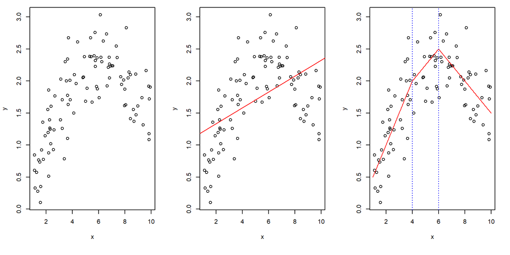

## What are occupancy models

- Developed by MacKenzie and colleagues (MacKenzie, D.I., Nichols, J.D., Lachman, G.B., Droege, S., Andrew Royle, J. and Langtimm, C.A., 2002. Estimating site occupancy rates when detection probabilities are less than one. Ecology, 83(8), pp.2248-2255.)
- It is a hierarchical Bayesian model that includes an observation sub-model and a process sub-model

Observation:  
\[y_{i,j} \sim Binomial(z_{i} \times p, J_{i})\] Process: \[z_{i} \sim Bernoulli(\pi_{i})\] \[logit(\pi_{i}) = x^T \beta\]

## Case study

- Lion beetle in Alberta, Canada
- Relate lion beetle occurrence with temperature and forest cover
- Predict lion beetle distribution

## Study area and survey sites

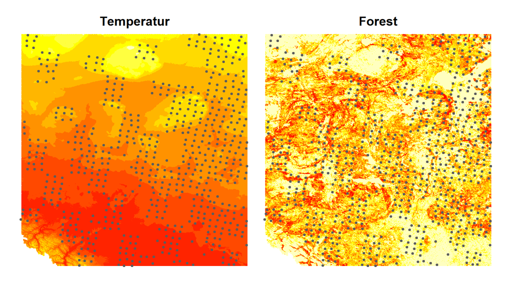

## Look at the data

```r
load('c:/A. UFL/rmeetup/rmeetup data.RData')
head(data, n=3)
```

```
##   y1 y2 y3 y4 temperature    forest
## 1  0  0  0  0   -2.432446 1.0000000
## 2  0  1  0  0    1.127675 0.0000000
## 3  1  1  1  1    1.127675 0.7039379
```

## Things can get complicated quickly

| Distribution-environment relationship | Model |
| --- | --- |
| Linear, additive | Temperature |
|  | Forest |
|  | Temperature + Forest |
| Non-linear, additive | Temperature ^ 2 |
|  | Forest ^ 2 |
|  | Temperature ^ 2 + Forest |
|  | Temperature + Forest ^ 2 |
|  | Temperature ^ 2 + Forest ^ 2 |

## And more

| Distribution-environment relationship | Model |
| --- | --- |
| Interaction | Temperature * Forest |
|  | (Temperature ^ 2) * Forest |
|  | Temperature * (Forest ^ 2) |
|  | (Temperature ^ 2) * (Forest ^ 2) |

## Use MARS to make things easier

```r
library(earth) # This is the library for MARS
```

```r
# Create "occupancy" data for MARS
data$y01 <- ifelse(rowSums(data[,1:4])==0, 0, 1)
head(data, n=3)
```

```
##   y1 y2 y3 y4 temperature    forest y01
## 1  0  0  0  0   -2.432446 1.0000000   0
## 2  0  1  0  0    1.127675 0.0000000   1
## 3  1  1  1  1    1.127675 0.7039379   1
```

## Use MARS to analyze the data

```r
# Model one, only additive relationships are considered
fit1 <- earth(y01 ~ temperature + forest, data=data,
              glm=list(family='binomial'), # for occurrence data
              degree=1, # for additive model
              pmethod='backward', nfold=20, keepxy=TRUE) # for k-fold cross validation
```

```r
# Model two, consider interactions between covariates
fit2 <- earth(y01 ~ temperature + forest, data=data,
              glm=list(family='binomial'),
              degree=2, # include level-one interactions
              pmethod='backward', nfold=20, keepxy=TRUE)
```